Stakeholder report · public health expert

# Viral vs bacterial notifiable diseases after COVID-19, 2021–2025

How have viral and bacterial infectious diseases in Switzerland developed in the years after COVID (2021-2025)?

Source: FOPH Infectious Disease Dashboard (IDD) exports, published up to 2026-09-30. National level (Switzerland + Liechtenstein), all ages, all sexes. Generated automatically by the harmonisation pipeline.

Viral (excl. COVID-19), vs 2019

+123%

2021→2025: +1213% (2,866 → 37,638)

Bacterial, vs 2019

+23%

2021→2025: +32% (32,672 → 43,152)

COVID-19 notifications

-98%

peak 2022: 3,045,024

Strongest rise

Influenza

+7851% since 2021

## Viral vs bacterial, indexed to 2019

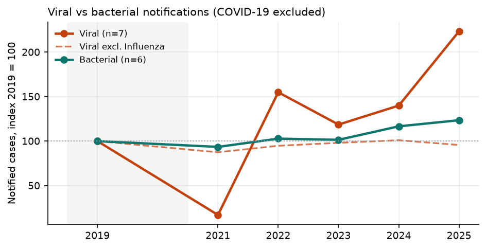

Sum of notified cases per group, 2019 (pre-COVID) = 100. 2020 is not shown. Dashed lines remove influenza, which collapsed in 2021 under pandemic measures and otherwise dominates the viral total. COVID-19 is excluded from the viral total because its volume (up to millions of cases) would hide every other trend; it is shown in the table and per-disease charts.

## Per disease: incidence per 100,000

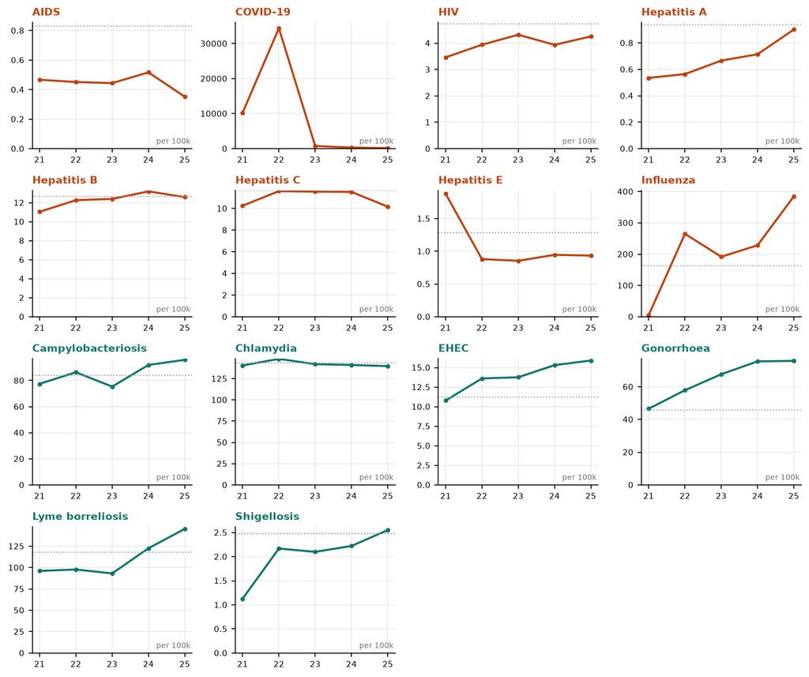

Dotted line = 2019 level. Orange = viral, teal = bacterial. Lyme borreliosis is a sentinel extrapolation, not a mandatory notification.

## Change table

| Disease | Class | 2019 | 2021 | 2022 | 2023 | 2024 | 2025 | 2021→2025 | vs 2019 | per 100k (2025) | Peak |
| --- | --- | --- | --- | --- | --- | --- | --- | --- | --- | --- | --- |
| AIDS | viral | 72 | 41 | 40 | 40 | 47 | 32 | -22% | -56% | 0.4 | 2024 |
| COVID-19* | viral | – | 900,839 | 3,045,024 | 67,951 | 28,389 | 13,740 | -98% | – | 151.1 | 2022 |
| HIV | viral | 409 | 304 | 349 | 389 | 358 | 387 | +27% | -5% | 4.3 | 2023 |
| Hepatitis A | viral | 81 | 47 | 50 | 60 | 65 | 82 | +74% | +1% | 0.9 | 2025 |
| Hepatitis B | viral | 1,094 | 969 | 1,086 | 1,116 | 1,199 | 1,144 | +18% | +5% | 12.6 | 2024 |
| Hepatitis C | viral | 1,008 | 900 | 1,027 | 1,040 | 1,048 | 924 | +3% | -8% | 10.2 | 2024 |
| Hepatitis E | viral | 111 | 165 | 78 | 77 | 86 | 85 | -48% | -23% | 0.9 | 2021 |
| Influenza | viral | 14,069 | 440 | 23,466 | 17,253 | 20,766 | 34,984 | +7851% | +149% | 384.8 | 2025 |
| Campylobacteriosis | bacterial | 7,253 | 6,802 | 7,645 | 6,784 | 8,360 | 8,716 | +28% | +20% | 95.9 | 2025 |
| Chlamydia | bacterial | 12,409 | 12,335 | 13,131 | 12,790 | 12,827 | 12,707 | +3% | +2% | 139.8 | 2022 |
| EHEC | bacterial | 970 | 947 | 1,205 | 1,239 | 1,392 | 1,446 | +53% | +49% | 15.9 | 2025 |
| Gonorrhoea | bacterial | 3,942 | 4,088 | 5,127 | 6,091 | 6,868 | 6,894 | +69% | +75% | 75.8 | 2025 |
| Lyme borreliosis | bacterial | 10,155 | 8,402 | 8,621 | 8,354 | 11,101 | 13,158 | +57% | +30% | 145.4 | 2025 |
| Shigellosis | bacterial | 214 | 99 | 192 | 189 | 202 | 232 | +134% | +8% | 2.6 | 2025 |

Hover any number to see the exact source file and row(s). * excluded from group totals. Rising/falling = change of more than ±15%.

## Context: GP consultations for respiratory syndromes

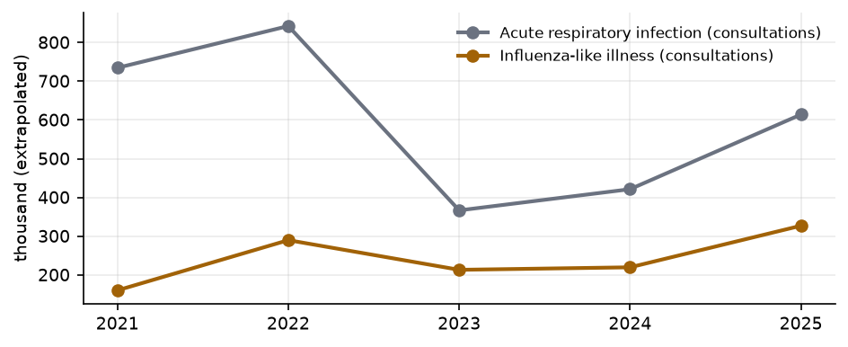

Sentinella estimates; mixed viral and bacterial causes, so not assigned to either group.

## Datasets not used in this report, and why

| Topic | Class | Reason |
| --- | --- | --- |
| covid19 | viral | no count measure (has: samples_sentinella) |
| respiratory_pathogens | surveillance_signal | no count measure (has: samples) |
| wastewater_sequencing | surveillance_signal | no total rows with values |
| wastewater_viral_load | surveillance_signal | no count measure (has: influenza_a, influenza_b, respiratory_syncytial_virus, sars-cov-2) |

## Data quality

84 checks passed, 0 warnings, 0 failures on the 16 datasets used.

| Dataset | Check | Status | Detail |
| --- | --- | --- | --- |

## Sources and traceability

20 unique datasets harmonised (17 duplicate downloads detected by file fingerprint and skipped). Every value in this report is listed with its source file and row in `report_public_health_expert_trace.csv`.

| Topic | System | Published | Used | File | SHA-256 | Rows |
| --- | --- | --- | --- | --- | --- | --- |
| aids | mandatory_reporting_system | 2026-09-02 | yes | `AIDS_oblig/data.csv` | `906ec0d77eba` | 13 |
| campylobacteriosis | mandatory_reporting_system | 2026-09-09 | yes | `CAMPYLOBACTERIOSIS_oblig/data.csv` | `19b915920c0f` | 755 |
| chlamydiosis | mandatory_reporting_system | 2026-09-02 | yes | `CHLAMYDIOSIS_oblig/data.csv` | `33301a7f552e` | 783 |
| covid19 | swiss_pathogen_surveillance_platform | 2026-09-30 | no | `COVID19_genomic_surveillance/data.csv` | `8440ae29f194` | 198 |
| covid19 | mandatory_reporting_system | 2026-09-30 | yes | `COVID19_oblig/data.csv` | `884387436099` | 13,501 |
| acute_respiratory_infection | sentinella_reporting_system | 2026-09-30 | yes | `COVID19_sentinella/data.csv` | `39c3d8533367` | 5,229 |
| wastewater_sequencing | swiss_federal_institute_of_technology | 2026-09-30 | no | `COVID19_wastewater_sequencing/data.csv` | `ca4ca4fc3a11` | 226,596 |
| ehec | mandatory_reporting_system | 2026-09-09 | yes | `EHEC_oblig/data.csv` | `8f9109a49ed0` | 771 |
| gonorrhea | mandatory_reporting_system | 2026-09-02 | yes | `GONORRHEA_oblig/data.csv` | `e8da3a7b21d8` | 777 |
| hepatitis_a | mandatory_reporting_system | 2026-09-09 | yes | `HEPATITIS_A_oblig/data.csv` | `af364adc8c31` | 745 |
| hepatitis_b | mandatory_reporting_system | 2026-09-02 | yes | `HEPATITIS_B_oblig/data.csv` | `efca8a94f34e` | 829 |
| hepatitis_c | mandatory_reporting_system | 2026-09-02 | yes | `HEPATITIS_C_oblig/data.csv` | `dafc82712a52` | 829 |
| hepatitis_e | mandatory_reporting_system | 2026-09-09 | yes | `HEPATITIS_E_oblig/data.csv` | `9f9612b83428` | 536 |
| hiv | mandatory_reporting_system | 2026-09-02 | yes | `HIV_oblig/data.csv` | `a382cd7fa6bd` | 777 |
| influenza | mandatory_reporting_system | 2026-09-30 | yes | `INFLUENZA_oblig/data.csv` | `b99973369aad` | 31,028 |
| influenza-like_illness | sentinella_reporting_system | 2026-09-30 | yes | `INFLUENZA_sentinella/data.csv` | `880cad3cb3d9` | 12,366 |
| lyme_borreliosis | sentinella_reporting_system | 2026-09-16 | yes | `LYME_sentinella/data.csv` | `86357493561b` | 522 |
| respiratory_pathogens | national_reference_center_for_influenza | 2026-09-30 | no | `RESPVIRUSES_sentinella/data.csv` | `32f85c96135a` | 5,008 |
| wastewater_viral_load | swiss_federal_institute_of_aquatic_science_and_technology | 2026-09-30 | no | `RESPVIRUSES_wastewater (3)/data.csv` | `98e92f9a9020` | 74,580 |
| shigellosis | mandatory_reporting_system | 2026-09-09 | yes | `SHIGELLOSIS_oblig/data.csv` | `f3b6c8f59d39` | 745 |